# HMC analysis of a linear regression with autoregressive error using rtan applied to the approval rates of President Reagan

Claudia Czado

25 June, 2020

```r
knitr::opts_chunk$set(cache = TRUE)
```

# Preliminaries

## Installing *Rtools*

- First one needs to install *Rtools*. Installation is described under *http://jtleek.com/modules/01_DataScientistToolbox/02_10_rtools/#1*
- Downloads of *Rtools* you can find under *https://cran.r-project.org/bin/windows/Rtools/*
- After *Rtools* is installed install in Rstudio the package *devtools*

## Installing R package *bayesjackman*

- In *Rstudio* type into the console window

*devtools::install_github(“jrnold/jackman-bayes”, subdir = “bayesjackman”)*

## Required R packages

- bayesjackman (contains rstan codes for the examples of Simon Jackman)
- rafalib
- rstan
- tidyverse

# Package *bayesjackman*

- Under *https://jrnold.github.io/bugs-examples-in-stan/* you can find a description of **Simon Jackman’s Bayesian Model Examples in Stan** by Jeffrey B. Arnold.
- His work is licensed under the Creative Commons Attribution 4.0 International License *https://creativecommons.org/licenses/by /4.0/*
- The following analysis is based on his code.

# Approval rates of President Reagan

The data set *ReaganApproval* is contained in the R package *bayesjackman* and gives the *approval rating* of President Reagan over 96 months together with the corresponding *unemployment* and *inflation rates*.

```r
data("ReaganApproval", package = "bayesjackman")
head(ReaganApproval)
```

```
## # A tibble: 6 x 3
##     app  infl unemp
##   <dbl> <dbl> <dbl>
## 1    51 11.8    7.5
## 2    55 11.4    7.4
## 3    60 10.6    7.4
## 4    67 10.1    7.2
## 5    68  9.79   7.5
## 6    59  9.70   7.5
```

# Exploring the data

```r
summary(ReaganApproval)
```

```
##       app             infl            unemp
##  Min.   :35.00   Min.   : 1.187   Min.   : 5.300
##  1st Qu.:47.75   1st Qu.: 3.454   1st Qu.: 6.600
##  Median :53.50   Median : 4.009   Median : 7.250
##  Mean   :53.15   Mean   : 4.667   Mean   : 7.536
##  3rd Qu.:60.00   3rd Qu.: 4.638   3rd Qu.: 8.350
##  Max.   :68.00   Max.   :11.795   Max.   :10.800
```

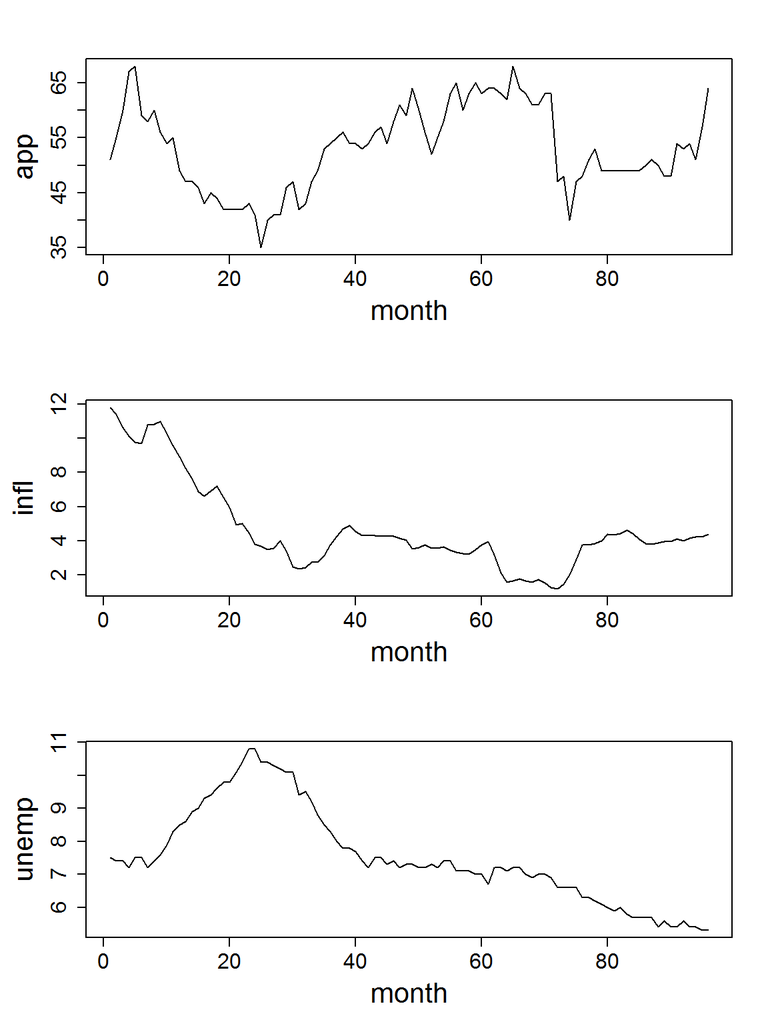

```r
bigpar(3,1)
plot(1:96,ReaganApproval$app,type="l",ylab="app",xlab="month")
plot(1:96,ReaganApproval$infl,type="l",ylab="infl",xlab="month")
plot(1:96,ReaganApproval$unemp,type="l",ylab="unemp",xlab="month")
```

## Fitting a linear model

```r
r<-lm(app~infl+unemp, data=ReaganApproval)
summary(r)
```

```
##
## Call:
## lm(formula = app ~ infl + unemp, data = ReaganApproval)
##
## Residuals:
##      Min       1Q   Median       3Q      Max
## -15.0441  -5.2482  -0.3239   5.2555  14.5863
##
## Coefficients:
##             Estimate Std. Error t value Pr(>|t|)
## (Intercept)  71.8381     3.7757  19.026  < 2e-16 ***
## infl          0.2038     0.2763   0.738    0.463
## unemp        -2.6065     0.4850  -5.375 5.66e-07 ***
## ---
## Signif. codes:  0 '***' 0.001 '**' 0.01 '*' 0.05 '.' 0.1 ' ' 1
##
## Residual standard error: 6.828 on 93 degrees of freedom
## Multiple R-squared:  0.237,  Adjusted R-squared:  0.2206
## F-statistic: 14.44 on 2 and 93 DF,  p-value: 3.448e-06
```

## Checking residuals over time

The residuals are correlated over time

```r
round(cor(resid(r)[1:95],resid(r)[2:96]),digits=2)
```

```
## [1] 0.85
```

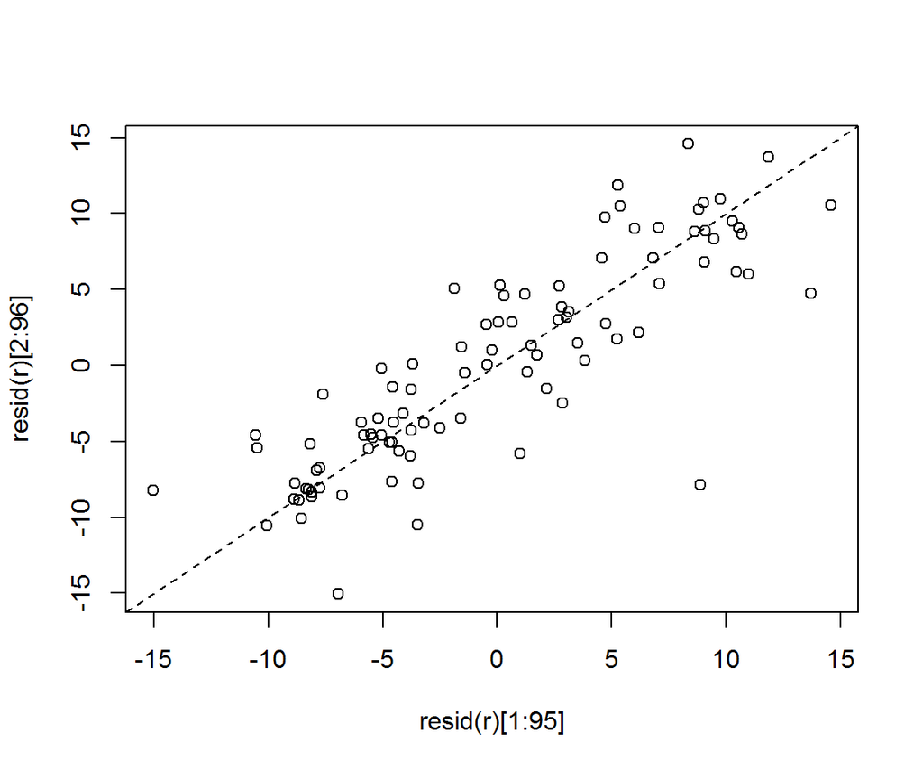

```r
plot(resid(r)[1:95],resid(r)[2:96])
abline(0,1,lty=2)
```

# Model formulation for the linear model with autoregressive disturbances

- $y_i=\mu_i+\epsilon_i+\theta \epsilon_{i-1}$
- $\mu_i=\alpha+x^\top\beta$ and $\epsilon_{i} \sim Normal(0,\sigma^2)$, i.i.d. for $i \in 1,.,N$.

Weakly informative priors for each parameter are used,

# Setup the data for running *rstan*

```r
reagan_data <- within(list(), {
  y <- ReaganApproval$app
  N <- length(y)
  X <- model.matrix(~ 0 + infl + unemp, data = ReaganApproval) %>% scale()
  K <- ncol(X)
  alpha_loc <- 0
  alpha_scale <- 10
  beta_loc <- rep(0, K)
  beta_scale <- rep(2.5 * sd(y), K)
  sigma_scale <- 5 * sd(y)
  theta_a <- 1
  theta_b <- 1
})
```

# Setup for a linear regression model with autoregressive errors to be used in *rstan*

In the file *regar1.stan* the stan model formulation for a linear regression model with autoregressive error is given. This takes some time when you run it the first time.

```r
mod_regar1 <- stan_model("regar1.stan")
```

To see the stan code type:

```r
mod_regar1
```

```
## S4 class stanmodel 'regar1' coded as follows:
## data {
##   // number of observations
##   // need at least two to estimates
##   int<lower = 2> N;
##   // response
##   vector[N] y;
##   // regression design matrix
##   int<lower = 1> K;
##   matrix[N, K] X;
##   // priors
##   real alpha_loc;
##   real<lower = 0.> alpha_scale;
##   vector[K] beta_loc;
##   vector<lower = 0.>[K] beta_scale;
##   real<lower = 0.> sigma_scale;
##   real<lower = 0.> theta_a;
##   real<lower = 0.> theta_b;
## }
## parameters {
##   // regression coefficients
##   real alpha;
##   vector[K] beta;
##   // error scale
##   real<lower=0> sigma;
##   // lag coefficients
##   real<lower = 0, upper = 1> theta_raw;
## }
## transformed parameters {
##   // observation means
##   vector[N] mu;
##   // error terms
##   vector[N] epsilon;
##   // lag coefficient;
##   real<lower = -1, upper = 1> theta;
##   // convert range of theta from (0, 1) to (-1, 1)
##   theta = (2. * theta_raw - 1.);
##   // regression
##   mu = alpha + X * beta;
##   // construct errors
##   epsilon[1] = y[1] - mu[1];
##   for (i in 2:N) {
##     epsilon[i] = y[i] - mu[i] - theta * epsilon[i - 1];
##   }
## }
## model {
##   alpha ~ cauchy(alpha_loc, alpha_scale);
##   beta ~ cauchy(beta_loc, beta_scale);
##   theta_raw ~ beta(theta_a, theta_b);
##   sigma ~ cauchy(0, sigma_scale);
##   for (i in 2:N) {
##     y[i] ~ normal(mu[i] + theta * epsilon[i - 1], sigma);
##   }
## }
```

# Run a MCMC using Hamiltonian Monte Carlo using *rstan*

The function *sampling* performs the sampling. Some of its defaults are

- chains=4
- iter=2000
- warmup=floor(iter/2)
- thin=1
- init=‘random’
- show_messages=TRUE

For details you can find with the help function.

```r
help("sampling,stanmodel-method")
```

```r
reagan_fit <- sampling(mod_regar1, data = reagan_data)
```

# Summary output of the HMC samples

```r
out_reagan<-round(summary(reagan_fit, par = c("alpha", "beta", "theta", "sigma"))$summary,digits=3)
out_reagan
```

```
##           mean se_mean    sd   2.5%    25%    50%    75%  97.5%    n_eff  Rhat
## alpha   53.183   0.012 0.840 51.506 52.619 53.184 53.741 54.808 5132.661 0.999
## beta[1]  0.654   0.013 0.908 -1.086  0.054  0.660  1.262  2.437 5062.125 1.000
## beta[2] -3.709   0.012 0.871 -5.402 -4.323 -3.714 -3.127 -1.995 4945.883 1.000
## theta    0.675   0.001 0.056  0.555  0.639  0.678  0.715  0.775 5087.515 1.000
## sigma    4.902   0.005 0.370  4.241  4.651  4.879  5.135  5.671 4827.370 0.999
```

# Trace plots of the HMC sample

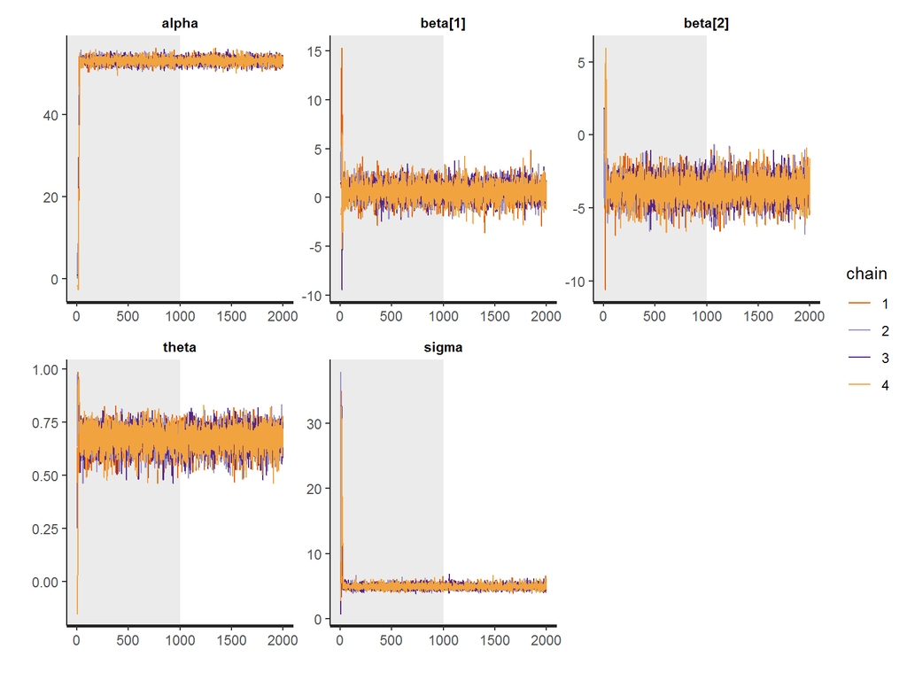

```r
traceplot(reagan_fit,par = c("alpha", "beta", "theta", "sigma"),inc_warmup=TRUE)
```

# Marginal posterior density estimates

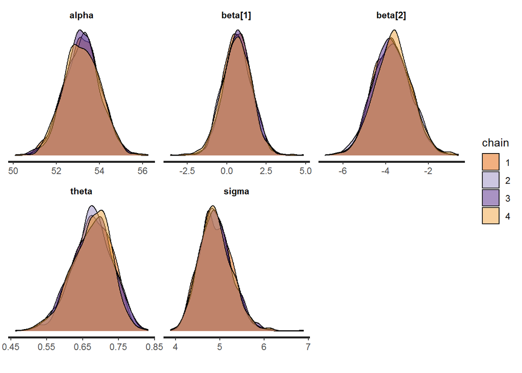

```r
stan_dens(reagan_fit,par = c("alpha", "beta", "theta", "sigma"),separate_chains=TRUE)
```

# Estimated posterior autocorrelations

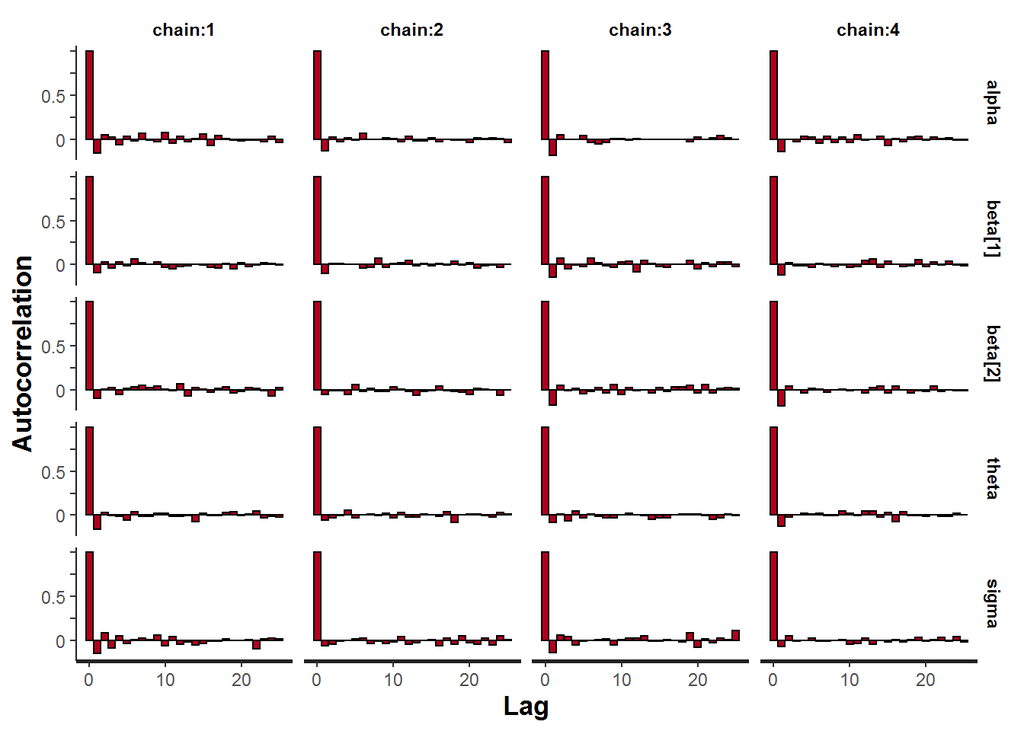

```r
stan_ac(reagan_fit,par = c("alpha", "beta", "theta", "sigma"),separate_chains=TRUE)
```